# Analysis on Red Wines Quality by LINA TA

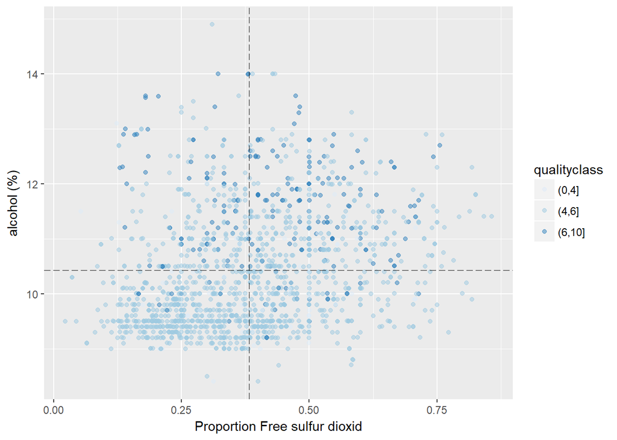

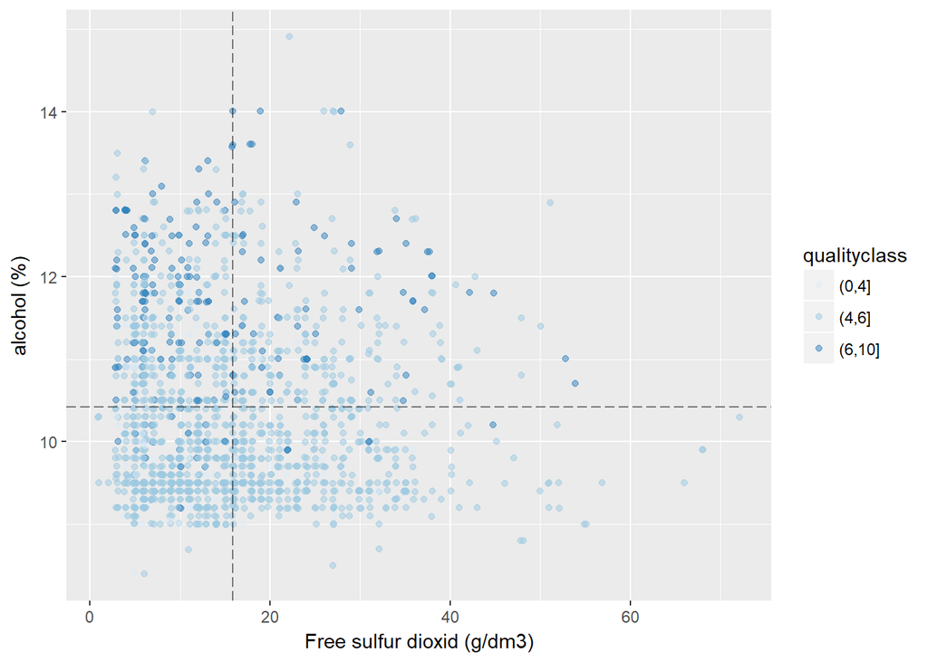

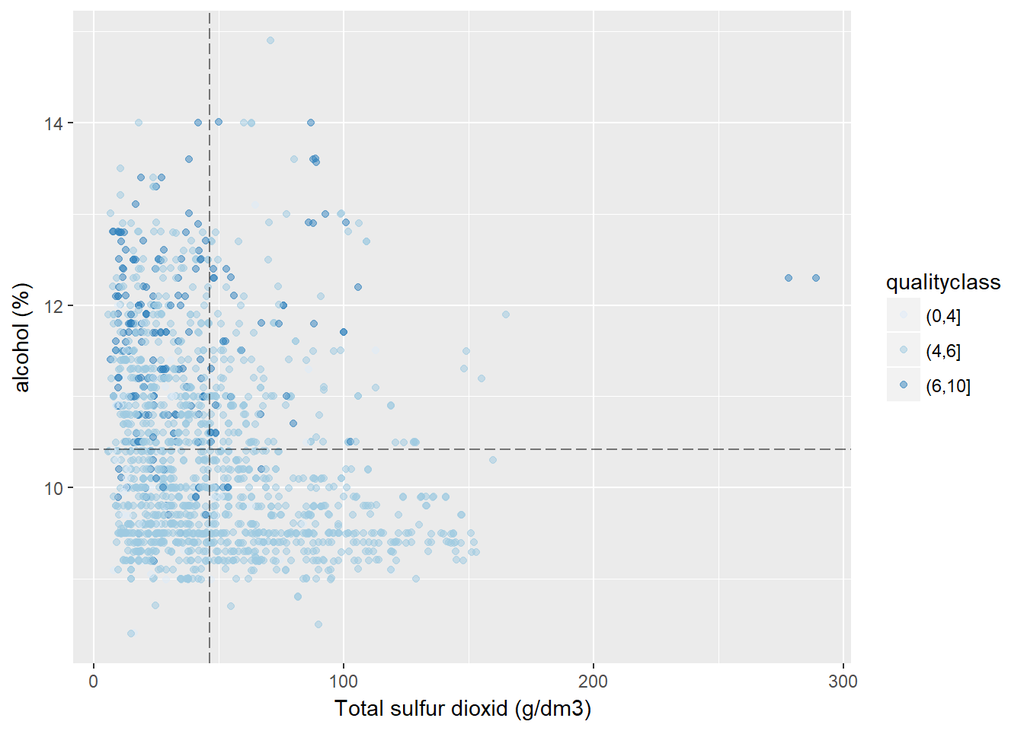

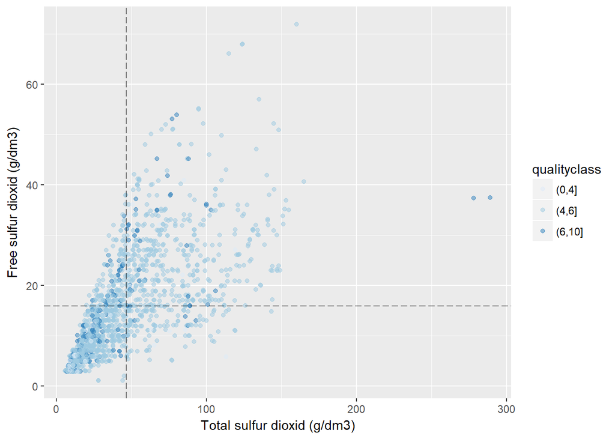

# Multivariate Analysis

### Talk about some of the relationships you observed in this part of the investigation. Were there features that strengthened each other in terms of looking at your feature(s) of interest?

We made different classes of the wine quality rating: - [0,4] considered as poor quality - [4,6] considered as medium quality - [6,10] considered as good quality

### Were there any interesting or surprising interactions between features?

As we saw in the univariate and bivariate analysis, we had the intuition that there might be a positive relation between the proportion of free sulfur dioxide on total and wine quality. - From the plot, the relation is indeed not as apparent. The distribution of good wines on the proportion axis are quite spread. - The observation is relatively the same for free sulfur dioxide’s multivariate plot. - However for the total sulfur dioxide’s multivariate plot, the result is more apparent. Good wines have a total sulfur dioxide generally lower than 46.47 g / dm3 (sample mean). - when we plot free sulfur dioxide, total sulfur dioxid and quality, we can see no apparent trend.

### OPTIONAL: Did you create any models with your dataset? Discuss the strengths and limitations of your model.

# Final Plots and Summary

### Wine Quality distribution

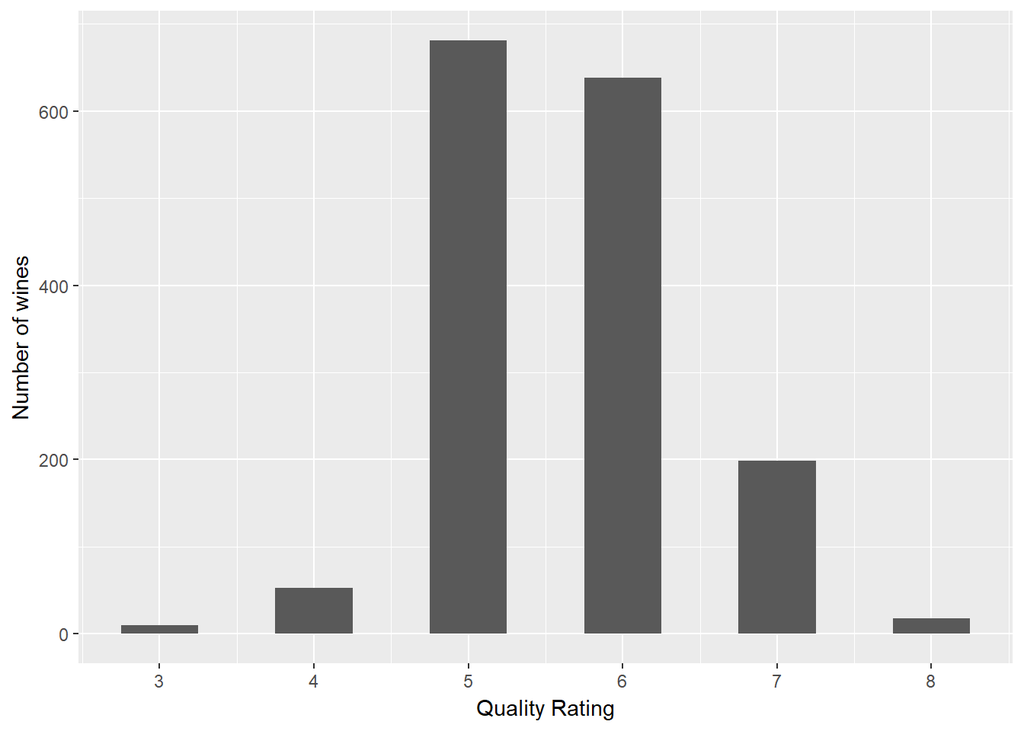

We analysed here 1599 red wines under 11 differents criteria measuring their acidity, sugar, chloride, sulfur dioxide, density, pH, sulphates, alcohol and these wines have been rated between 0 and 10. We can observe than most of the wines are rated between 5 and 6.

### Relation between alcohol, citric acid, volatile acidity and quality

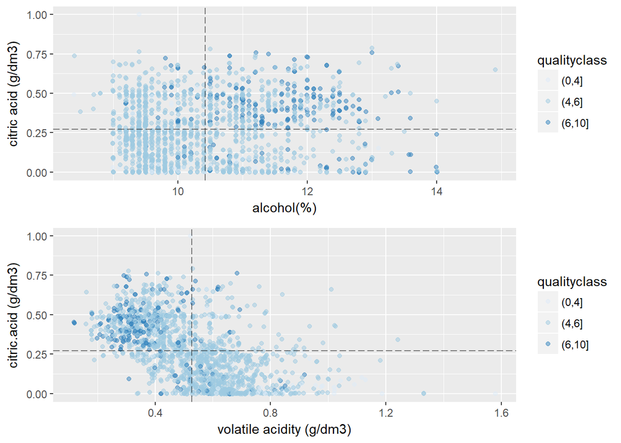

### Relation between sulfur dioxid and wine quality

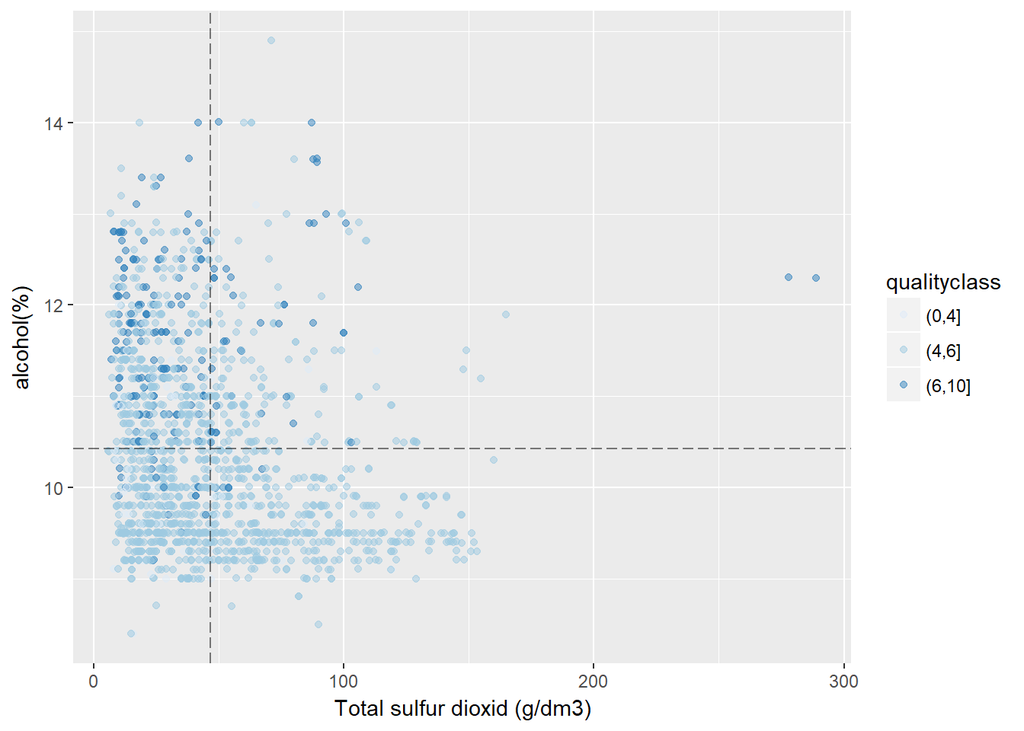

Finally the level of sulfur dioxid in the wine is also a determinant in qualty rating. Most of the good wines have total sulfur dioxid level lower than 46.47 g / dm3. We thought the level of free sulfur dioxid compared to bound can be an element of differentiation, but not in this sample. It is more the total sulfur dioxid level that counts.

# Reflection

This was a very interesting project and dataset to analyse. Intuitively, I would not think that the alcohol level would be a determinant in the wine quality. Usually, we would judge at the taste including acidity, sweetness, flavors, the density, the odor. But the sweetness, density and pH did not have much impact on this sample.

From the univariate analysis, I tried to figure out the difference between free and bound sulfur dioxid and made the hypothesis that a higher proportion of free sulfur dioxide compared to bound would be better for the preservation of the wine and wine quality. But it seems that I was wrong. I couldn’t draw any conclusion from bivariates and multivariates analysis. However, it is clear that total sulfur dioxide from a certain level negatively impact the wine taste and wine quality.

It would be interesting to analyse further this dataset or bring more parameters to this analysis to understand what impact the alcohol level and why it is such a major component in this dataset.